# STAT2401 Analysis of Experiments

Practice Examination Semester 1 2024

For Monday 10th June 2024

# STAT2401 Practice Examination - Semester 1 2024 (60 marks)

## Student name: Himakar Gadham

## Student ID: 23783777

# Instructions

1. You are provided with Rmd template for your working that you are strongly recommended to submit under Question 1 File Response for partial marks.
2. Save the RMD template (within the LMS, *right click ON the file, then Save Link As*) to your working directory and rename it in the format of *studentID_Surname.Rmd*, eg, *123456_Nur.Rmd*.
3. Marks for each question are shown. The total number of marks is 60.
   - This is a 2-hour examination.
   - You are provided with 15 minutes extra time for Rmarkdown template download, save and upload time.
   - There are 20 questions (Q2-Q21) set as multiple choice, multiple blanks, matching, calculated numeric. You must enter your answers on the LMS.
   - Include relevant R-output in your answers for some questions using R, if required.
     - You must provide your R code into the template provided here for full marks.
     - Incorrect answers with R code attempt will be allocated some partial marks.
     - If you have any question or comment about the exam or would like to alert your Unit Coordinator to a perceived error, include a comment in your working in Rmd file, if appropriate, to indicate how you interpreted the question.
   - Carry out all of your work in this Rmarkdown file.
4. **Save your work frequently!**
5. When you are finished, upload this *Rmarkdown file* back into *Question 1 File Response* on the LMS.
   - You only need to submit this RMD file.
   - You don’t need to knit this file.
   - DO NOT BE LATE. You must submit within the examination time (135 minutes). *We do not accept any Rmd submission by email.*

## Remarks

- You can add your working in this file whenever applicable, eg theoretical question. Clearly indicates the question number before your answer.
- Make sure your program works for every chunk.
- It is your responsibility to call the libraries of R packages.
- The following chunk listed some R packages for the datasets that you may need to load as libraries.

```r
## R packages for the datasets
library(datarium)
library(HSAUR2)
library(MASS)
library(ISLR)
```

# Based on Questions 2-21 on the LMS.

## Question 3

```r
x <- c(2,6,9, 14, 21,23)

y<- c(16,18,  26, 33, 28, 39)

# Calculate means
mean_x <- mean(x)
mean_y <- mean(y)

# Calculate the numerator and denominator for the slope
numerator <- sum((x - mean_x) * (y - mean_y))
denominator <- sum((x - mean_x)^2)

# Calculate the slope
slope <- numerator / denominator
round(0.9146, 3)
```

```
[1] 0.915
```

```r
fit <- lm(y~x)
summary(fit)
```

```
Call:
lm(formula = y ~ x)

Residuals:
     1      2      3      4      5      6
-1.023 -2.697  2.548  4.956 -6.474  2.690

Coefficients:
            Estimate Std. Error t value Pr(>|t|)
(Intercept)  15.1860     3.6851   4.121   0.0146 *
x             0.9185     0.2516   3.650   0.0218 *
---
Signif. codes:  0 ‘***’ 0.001 ‘**’ 0.01 ‘*’ 0.05 ‘.’ 0.1 ‘ ’ 1

Residual standard error: 4.704 on 4 degrees of freedom
Multiple R-squared:  0.7691,    Adjusted R-squared:  0.7114
F-statistic: 13.32 on 1 and 4 DF,  p-value: 0.02177
```

Which of the following statements is (are) FALSE?

```
a.
```

A scatter plot is a useful graphical tool for displaying the strength of the relationship between two quantitative variables.

```
b.
```

A categorical variable can be added to a scatter plot by using a different color or symbol for each category.

```
c.
```

If above-average values of two quantitative variables and below-average values of the same two quantitative variables tend to occur together, the two variables are positively associated.

```
d.
```

An individual value that deviates from the overall pattern displayed on a scatter plot is called an outlier.

```
e.
```

The only relationship that a scatter plot can usefully display is linear with no outliers.

## Question 5

```r
# Data
women <- c(64, 65, 65, 66, 66, 67, 68, 70)
men <- c(68, 68, 69, 70, 72, 72, 73, 75)
# Fit the linear regression model
fit <- lm(men ~ women)
summary(fit)
```

```
Call:
lm(formula = men ~ women)

Residuals:
    Min      1Q  Median      3Q     Max
-1.1546 -0.4070 -0.0314  0.1582  1.5942

Coefficients:
            Estimate Std. Error t value Pr(>|t|)
(Intercept) -12.1739    11.1365  -1.093 0.316259
women         1.2512     0.1677   7.460 0.000299 ***
---
Signif. codes:  0 ‘***’ 0.001 ‘**’ 0.01 ‘*’ 0.05 ‘.’ 0.1 ‘ ’ 1

Residual standard error: 0.8531 on 6 degrees of freedom
Multiple R-squared:  0.9027,    Adjusted R-squared:  0.8865
F-statistic: 55.65 on 1 and 6 DF,  p-value: 0.0002992
```

```r
# Perform ANOVA
anova_output <- anova(fit)
anova_output
```

```
Analysis of Variance Table

Response: men
          Df Sum Sq Mean Sq F value    Pr(>F)
women      1 40.508  40.508  55.654 0.0002992 ***
Residuals  6  4.367   0.728
---
Signif. codes:  0 ‘***’ 0.001 ‘**’ 0.01 ‘*’ 0.05 ‘.’ 0.1 ‘ ’ 1
```

```r
summary(fit)$r.squared
```

```
[1] 0.9026819
```

## Question 6

```r
# Given values
SST <- 133.46949
SSR <- 105.96390
n <- 14
DF_regression <- 1
DF_total <- n - 1
DF_error <- DF_total - DF_regression

# Calculate SSE
SSE <- SST - SSR

# Calculate MSE
MSE <- SSE / DF_error

# Output the result
MSE
```

```
[1] 2.292133
```

## Question 8

```r
# Given values
intercept <- 116.95
slope <- -0.26
goals_allowed <- 170

# Calculate the predicted winning percentage
predicted_winning_percentage <- intercept + (slope * goals_allowed)

# Output the result
predicted_winning_percentage
```

```
[1] 72.75
```

## Question 9

```r
# Calculate p-value for two-tailed test
t_statistic_slope <- 2
df <- 100 - 2
p_value_slope <- 2* pt(-abs(t_statistic_slope), df)
round(p_value_slope, 2)
```

```
[1] 0.05
```

## Question 10

```r
women <- c(64,65,65,66,66,67,68,70)
men <-c(68,68,69,70,72,72, 73,75)

fitw <- lm(women ~ men)
summary(fitw)
```

```
Call:
lm(formula = women ~ men)

Residuals:
     Min       1Q   Median       3Q      Max
-1.18663 -0.21518  0.03482  0.35446  0.69916

Coefficients:
            Estimate Std. Error t value Pr(>|t|)
(Intercept) 15.24234    6.85795   2.223 0.067956 .
men          0.72145    0.09671   7.460 0.000299 ***
---
Signif. codes:  0 ‘***’ 0.001 ‘**’ 0.01 ‘*’ 0.05 ‘.’ 0.1 ‘ ’ 1

Residual standard error: 0.6478 on 6 degrees of freedom
Multiple R-squared:  0.9027,    Adjusted R-squared:  0.8865
F-statistic: 55.65 on 1 and 6 DF,  p-value: 0.0002992
```

## Question 11

```r
gpa=c(3.1,    2.3,    3,    1.9,    2.5,    3.7,    3.4,    2.6,    2.8,    1.6,    2,    2.9,    2.3,    3.2,    1.8,    1.4,    2,    3.8,    2.2,    1.5)
ets=c(5.5,    4.8,    4.7,    3.9,    4.5,    6.2,    6,    5.2,    4.7,    4.3,    4.9,    5.4,    5,    6.3,    4.6,    4.3,    5,    5.9,    4.1,    4.7)
fitp <- lm(gpa ~ ets)
summary(fitp)
```

```
Call:
lm(formula = gpa ~ ets)

Residuals:
     Min       1Q   Median       3Q      Max
-0.74803 -0.37100  0.01404  0.34792  0.75197

Coefficients:
            Estimate Std. Error t value Pr(>|t|)
(Intercept)  -1.6996     0.7268  -2.338   0.0311 *
ets           0.8399     0.1440   5.831  1.6e-05 ***
---
Signif. codes:  0 ‘***’ 0.001 ‘**’ 0.01 ‘*’ 0.05 ‘.’ 0.1 ‘ ’ 1

Residual standard error: 0.435 on 18 degrees of freedom
Multiple R-squared:  0.6538,    Adjusted R-squared:  0.6346
F-statistic:    34 on 1 and 18 DF,  p-value: 1.597e-05
```

```r
anova(fitp)
```

```
Analysis of Variance Table

Response: gpa
          Df Sum Sq Mean Sq F value    Pr(>F)
ets        1 6.4337  6.4337  33.998 1.597e-05 ***
Residuals 18 3.4063  0.1892
---
Signif. codes:  0 ‘***’ 0.001 ‘**’ 0.01 ‘*’ 0.05 ‘.’ 0.1 ‘ ’ 1
```

```r
ETS_value <- 4.0
confint(fitp, newdata = data.frame(ets = ETS_value),level = 0.90)
```

```
                   5 %       95 %
(Intercept) -2.9598386 -0.4392842
ets          0.5901246  1.0897000
```

```r
# Data
gpa <- c(3.1, 2.3, 3, 1.9, 2.5, 3.7, 3.4, 2.6, 2.8, 1.6, 2, 2.9, 2.3, 3.2, 1.8, 1.4, 2, 3.8, 2.2, 1.5)
ets <- c(5.5, 4.8, 4.7, 3.9, 4.5, 6.2, 6, 5.2, 4.7, 4.3, 4.9, 5.4, 5, 6.3, 4.6, 4.3, 5, 5.9, 4.1, 4.7)

# Fit the linear regression model
fit <- lm(gpa ~ ets)

# Summary of the model
summary(fit)
```

```
Call:
lm(formula = gpa ~ ets)

Residuals:
     Min       1Q   Median       3Q      Max
-0.74803 -0.37100  0.01404  0.34792  0.75197

Coefficients:
            Estimate Std. Error t value Pr(>|t|)
(Intercept)  -1.6996     0.7268  -2.338   0.0311 *
ets           0.8399     0.1440   5.831  1.6e-05 ***
---
Signif. codes:  0 ‘***’ 0.001 ‘**’ 0.01 ‘*’ 0.05 ‘.’ 0.1 ‘ ’ 1

Residual standard error: 0.435 on 18 degrees of freedom
Multiple R-squared:  0.6538,    Adjusted R-squared:  0.6346
F-statistic:    34 on 1 and 18 DF,  p-value: 1.597e-05
```

```r
# Coefficients
intercept <- coef(fit)[1]
slope <- coef(fit)[2]

# Point estimate for ETS = 4.0
ETS_value <- 4.0
point_estimate <- intercept + slope * ETS_value
cat("Point estimate for ETS = 4.0:", round(point_estimate, 3), "\n")
```

```
Point estimate for ETS = 4.0: 1.66
```

```r
# Predict with confidence interval
conf_interval <- predict(fit, newdata = data.frame(ets = ETS_value), interval = "confidence", level = 0.90)
cat("90% confidence interval for ETS = 4.0: (", round(conf_interval[1, 2], 3), ", ", round(conf_interval[1, 3], 4), ")\n")
```

```
90% confidence interval for ETS = 4.0: ( 1.359 ,  1.9615 )
```

```r
# Point estimate for ETS = 4.0
ETS_value <- 4.2
point_estimate <- intercept + slope * ETS_value
cat("Point estimate for ETS = 4.0:", round(point_estimate, 3), "\n")
```

[output not shown]

```r
# Predict with confidence interval
conf_interval <- predict(fit, newdata = data.frame(ets = ETS_value), interval = "confidence", level = 0.90)
cat("90% confidence interval for ETS = 4.0: (", round(conf_interval[1, 2], 3), ", ", round(conf_interval[1, 3], 3), ")\n")
```

[output not shown]

## Question 13

```r
dna<-c(0.148,0.276,0.156,0.3,0.108,0.214,0.112,0.116,0.18,0.33,0.28,0.12,0.218,0.24,0.308,0.064,0.152,0.1,0.238,0.228,0.589,0.463,0.461,0.333,0.357,0.382,0.414,0.241,0.458,0.396,0.307,0.236,0.076,0.001,0.009,0.099,0.187,0.104,0.088,0.072,0.192,0.152,0.152,0.272,0.288,0.232,0.368,0.216,0.248,0.28,0.336,0.32,0.896,0.2,0.408,0.472,0.648,0.384,0.44,0.592,0.392,0.312,0.312,0.208,0.128,0.264,0.264,0.328,0.264,0.376,0.288,0.208,0.224,0.376,0.6,0.168,0.264,0.152,0.184,0.312,0.344,0.184,0.36,0.264,0.464,0.328,0.296,1.056,0.538,0.09,0.13,0.207,0.153,0.206,0.172,0.131,0.095,0.307,0.171,0.822,0.901,0.552,0.391,0.172,0.116,0.168,0.074,0.1,0.132,0.112,0.121,0.162,0.302,0.179,0.369,0.213)
phyto <-c(0.01,0.056,0.032,0.022,0.009,0.023,0.016,0.008,0.008,0.016,0.005,0.004,0.006,0.007,0.005,0.006,0.006,0.006,0.011,0.01,0.05,0.038,0.034,0.02,0.023,0.032,0.034,0.012,0.036,0.033,0.018,0.002,0.001,0.002,0,0,0.001,0.004,0.009,0.002,0.005,0.028,0.006,0.004,0.046,0.006,0.003,0.011,0.006,0.002,0.062,0.006,0.055,0.017,0.018,0.017,0.034,0.008,0.042,0.032,0.036,0.002,0.003,0.001,0.001,0.001,0.008,0.01,0.002,0.003,0.001,0.024,0.017,0.01,0.024,0.014,0.018,0.01,0.016,0.017,0.009,0.01,0.01,0.026,0.03,0.028,0.01,0.082,0.055,0.003,0.001,0.001,0.001,0.001,0.001,0.001,0,0.001,0.001,0.058,0.075,0.04,0.026,0.006,0.003,0.005,0,0.001,0.005,0.003,0.004,0.001,0.014,0.002,0.023,0.007)

fitpy <- lm(dna ~ phyto)
summary(fitpy)
```

```
Call:
lm(formula = dna ~ phyto)

Residuals:
     Min       1Q   Median       3Q      Max
-0.33369 -0.06418 -0.00265  0.06684  0.29448

Coefficients:
            Estimate Std. Error t value Pr(>|t|)
(Intercept)  0.15231    0.01419   10.73   <2e-16 ***
phyto        8.16759    0.61629   13.25   <2e-16 ***
---
Signif. codes:  0 ‘***’ 0.001 ‘**’ 0.01 ‘*’ 0.05 ‘.’ 0.1 ‘ ’ 1

Residual standard error: 0.1136 on 114 degrees of freedom
Multiple R-squared:  0.6064,    Adjusted R-squared:  0.6029
F-statistic: 175.6 on 1 and 114 DF,  p-value: < 2.2e-16
```

```r
# Calculate Cook's distances
cooks_d <- cooks.distance(fitpy)

# Sort Cook's distances in descending order to find the third largest
sorted_cooks_d <- sort(cooks_d, decreasing = TRUE)
sorted_cooks_d
```

```
          88           51            2           53          100          101           45            3           57           42
3.979928e-01 3.399861e-01 2.770894e-01 2.058433e-01 1.048497e-01 1.032378e-01 8.687059e-02 4.448754e-02 3.593704e-02 2.772558e-02
          75           60           70           47           34           35           98           62           56           58
2.706537e-02 2.130922e-02 2.075141e-02 1.911803e-02 1.557136e-02 1.280989e-02 1.261668e-02 1.138706e-02 1.121022e-02 1.119889e-02
           7           89           63           71           72           16           74           39           50            6
9.945923e-03 9.578650e-03 9.558809e-03 9.556817e-03 8.414647e-03 8.384393e-03 7.549292e-03 7.374796e-03 6.870868e-03 6.494905e-03
          66           52           15           83          102           81            5           40           69           84
6.298178e-03 6.264288e-03 6.178241e-03 5.944079e-03 5.752377e-03 5.423610e-03 5.389614e-03 5.174763e-03 5.038298e-03 4.793970e-03
          18           33            8           55           90          107           44           59           11           79
4.564318e-03 4.193327e-03 4.181206e-03 4.106779e-03 3.941282e-03 3.824794e-03 3.744411e-03 3.707307e-03 3.533106e-03 3.333324e-03
          76           68           38           54            1           85           61           78           32          110
3.329402e-03 3.308576e-03 3.242127e-03 2.848165e-03 2.767172e-03 2.641282e-03 2.518761e-03 2.515695e-03 2.513913e-03 2.196740e-03
         108           12           97          111          105           36          109           73           21           86
2.149063e-03 2.087492e-03 2.048420e-03 2.023733e-03 1.933943e-03 1.772439e-03 1.750929e-03 1.545829e-03 1.489075e-03 1.485062e-03
          87           64           92           94           17           43           49           82           67           10
1.439641e-03 1.327335e-03 1.272065e-03 1.217971e-03 1.081327e-03 1.081327e-03 9.693297e-04 9.350804e-04 8.695015e-04 7.518658e-04
          23           26           65            9           91           96           30           77          113           46
7.265278e-04 6.720211e-04 6.196994e-04 5.735510e-04 5.457178e-04 5.104899e-04 4.751638e-04 4.338448e-04 4.274343e-04 4.187941e-04
          37            4           14          104          115          103          106           48           27           80
4.134892e-04 4.004346e-04 3.944719e-04 3.820671e-04 3.393854e-04 3.281466e-04 2.960963e-04 2.480105e-04 1.936926e-04 1.489353e-04
          13           29           25           24           95           99          114           93           28           31
1.238449e-04 1.159853e-04 1.157101e-04 1.096852e-04 7.807031e-05 6.511135e-05 5.945197e-05 3.282456e-05 3.068429e-05 2.049421e-05
          20           19          116          112           41           22
1.339450e-05 6.245494e-06 5.249014e-06 1.368770e-06 6.131013e-07 1.017736e-07
```

```r
# Get the third largest Cook's distance
third_largest_cooks_d <- sorted_cooks_d[3]
cat("The third largest Cook's distance is:", round(third_largest_cooks_d, 3), "\n")
```

```
The third largest Cook's distance is: 0.277
```

## Question 14

```r
sales=c(1843.01 ,134.48 ,469.66 ,467.65 ,2626.07 ,805.89 ,909.5 ,77.77 ,1793.48 ,217.96 ,453.84 ,938.11 ,1962.19 ,2579.76 ,198.14 ,303.88 ,2361.85 ,949.87 ,360.61 ,2016.32 ,113.4 ,292.88 ,1386.37 ,140.51 ,387.87 ,551.11 ,284.24 ,341.5 ,299.84 ,151.12 ,68.64 ,1471.59 ,535.11 ,1642.11 ,370.22 ,249.12 ,557.65 ,236.64 ,112.87 ,674.44 ,1490.8 ,131.47 ,458.77 ,489.61 ,1659.04 ,1033.81 ,719.45 ,398.82 ,211.93 ,279.49 ,340.24 ,1098.96 ,1095.93 ,518.03 ,215.41 ,335.44 ,261.72 ,567.37 ,1355.82 ,339.61 ,350.2 ,1046.59 ,1203.1 ,1228.47 ,2791.35 ,992.64 ,232.92 ,288.3 ,209.14 ,342.31 ,484.31 ,107.77 ,1323.47 ,850.19 ,372.22 ,906.26 ,575.31 ,317.53 ,2279.96 ,638.49 ,591.37 ,1676.22 ,398.68 ,1458.04 ,152.77 ,1369.59 ,104.65 ,188.18 ,705.16 ,962.18 ,262.06 ,374.37 ,2093.83 ,246.62 ,458.35 ,996.14 ,495.68 ,411.5 ,143.29 ,1542.81)
adexp=c(950.1 ,231.1 ,606.8 ,486 ,891.3 ,762.1 ,456.5 ,18.5 ,821.4 ,444.7 ,615.4 ,791.9 ,921.8 ,738.2 ,176.3 ,405.7 ,935.5 ,916.9 ,410.3 ,893.6 ,57.9 ,352.9 ,813.2 ,9.9 ,138.9 ,202.8 ,198.7 ,603.8 ,272.2 ,198.8 ,15.3 ,746.8 ,445.1 ,931.8 ,466 ,418.6 ,846.2 ,525.2 ,202.6 ,672.1 ,838.1 ,19.6 ,681.3 ,379.5 ,831.8 ,502.8 ,709.5 ,428.9 ,304.6 ,189.7 ,193.4 ,682.2 ,302.8 ,541.7 ,150.9 ,697.9 ,378.4 ,860 ,853.7 ,593.6 ,496.6 ,899.8 ,821.6 ,644.9 ,818 ,660.2 ,342 ,289.7 ,341.2 ,534.1 ,727.1 ,309.3 ,838.5 ,568.1 ,370.4 ,702.7 ,546.6 ,444.9 ,694.6 ,621.3 ,794.8 ,956.8 ,522.6 ,880.1 ,173 ,979.7 ,271.4 ,252.3 ,875.7 ,737.3 ,136.5 ,11.8 ,893.9 ,199.1 ,298.7 ,661.4 ,284.4 ,469.2 ,64.8 ,988.3)

fit1 <- lm(sales ~ adexp)
fit2 <- lm(1/sales ~ adexp)
summary(fit1)
```

```
Call:
lm(formula = sales ~ adexp)

Residuals:
   Min     1Q Median     3Q    Max
-767.0 -276.0  -38.5  192.8 1530.4

Coefficients:
             Estimate Std. Error t value Pr(>|t|)
(Intercept) -168.6622    93.7803  -1.798   0.0752 .
adexp          1.7477     0.1567  11.150   <2e-16 ***
---
Signif. codes:  0 ‘***’ 0.001 ‘**’ 0.01 ‘*’ 0.05 ‘.’ 0.1 ‘ ’ 1

Residual standard error: 439.4 on 98 degrees of freedom
Multiple R-squared:  0.5592,    Adjusted R-squared:  0.5547
F-statistic: 124.3 on 1 and 98 DF,  p-value: < 2.2e-16
```

```r
summary(fit2)
```

```
Call:
lm(formula = 1/sales ~ adexp)

Residuals:
       Min         1Q     Median         3Q        Max
-0.0038686 -0.0009263 -0.0000789  0.0006436  0.0080540

Coefficients:
              Estimate Std. Error t value Pr(>|t|)
(Intercept)  6.624e-03  3.832e-04   17.29   <2e-16 ***
adexp       -7.153e-06  6.405e-07  -11.17   <2e-16 ***
---
Signif. codes:  0 ‘***’ 0.001 ‘**’ 0.01 ‘*’ 0.05 ‘.’ 0.1 ‘ ’ 1

Residual standard error: 0.001796 on 98 degrees of freedom
Multiple R-squared:   0.56, Adjusted R-squared:  0.5555
F-statistic: 124.7 on 1 and 98 DF,  p-value: < 2.2e-16
```

```r
# Calculate Cook's distances
cooks_d <- cooks.distance(fit2)

# Sort Cook's distances in descending order to find the third largest
sorted_cooks_d <- sort(cooks_d, decreasing = TRUE)
sorted_cooks_d
```

```
          31            8           92           87           72           39           25           21           26           53
4.785688e-01 2.959195e-01 1.116887e-01 7.037979e-02 6.117209e-02 5.193967e-02 4.496750e-02 4.355398e-02 4.313238e-02 3.323202e-02
          51            2           97           91           95           50           27           42            7           30
2.096729e-02 2.091144e-02 1.870056e-02 1.633564e-02 1.426339e-02 1.144963e-02 1.101593e-02 9.162351e-03 8.623073e-03 7.768439e-03
          86          100           44           46           58           85           37           29           94           18
7.428513e-03 7.372039e-03 7.117458e-03 6.775578e-03 6.494316e-03 5.730034e-03 5.537766e-03 5.323041e-03 5.082649e-03 4.680002e-03
          89           33           99           56           55           82           75           68           79           74
4.627142e-03 4.262751e-03 4.186196e-03 3.959345e-03 3.764822e-03 3.686612e-03 3.483964e-03 3.253202e-03 3.189116e-03 3.094329e-03
          38            1           64           62           24           14           10           34           48           81
2.920126e-03 2.758053e-03 2.668046e-03 2.660013e-03 2.384702e-03 2.281816e-03 2.263155e-03 2.139473e-03 1.966017e-03 1.733073e-03
           4           19           66           96           77           52           17           98           13           54
1.650610e-03 1.570572e-03 1.551861e-03 1.539610e-03 1.514359e-03 1.441677e-03 1.236247e-03 1.161851e-03 1.121620e-03 1.063943e-03
          22           71           32           69           88           80           28           35           65           76
1.043993e-03 9.877422e-04 9.349720e-04 8.257061e-04 7.780399e-04 6.630390e-04 6.593673e-04 5.785224e-04 5.748990e-04 5.401974e-04
          84           60           15           43           16           20           93           36           90           83
5.355289e-04 5.354298e-04 4.213567e-04 3.796561e-04 3.525571e-04 3.068413e-04 2.705540e-04 2.702834e-04 2.406287e-04 2.259590e-04
          40           49           59           78            9            5           61           73           47            3
2.239776e-04 1.958953e-04 1.842961e-04 1.477570e-04 1.236730e-04 7.630647e-05 7.518155e-05 6.011202e-05 5.731806e-05 4.082816e-05
          12           67           23           63           70           57           45            6           41           11
3.419299e-05 3.069194e-05 2.433742e-05 2.379997e-05 2.186062e-05 1.913404e-05 1.803874e-05 1.254101e-05 6.188057e-06 6.180831e-07
```

```r
# Get the third largest Cook's distance
third_largest_cooks_d <- sorted_cooks_d[2]
cat("The third largest Cook's distance is:", round(third_largest_cooks_d, 3), "\n")
```

[output not shown]

```r
# Calculate the cut-off for Cook's distance
cut_off_cooks_d <- 4 / length(sales)
cut_off_cooks_d
```

```
[1] 0.04
```

```r
# Perform the transformation (1/sales) vs adexp
inv_sales <- 1 / sales

# Fit the linear regression model with transformed data
fit_transformed <- lm(inv_sales ~ adexp)

# Summary of the transformed model
summary(fit_transformed)
```

```
Call:
lm(formula = inv_sales ~ adexp)

Residuals:
       Min         1Q     Median         3Q        Max
-0.0038686 -0.0009263 -0.0000789  0.0006436  0.0080540

Coefficients:
              Estimate Std. Error t value Pr(>|t|)
(Intercept)  6.624e-03  3.832e-04   17.29   <2e-16 ***
adexp       -7.153e-06  6.405e-07  -11.17   <2e-16 ***
---
Signif. codes:  0 ‘***’ 0.001 ‘**’ 0.01 ‘*’ 0.05 ‘.’ 0.1 ‘ ’ 1

Residual standard error: 0.001796 on 98 degrees of freedom
Multiple R-squared:   0.56, Adjusted R-squared:  0.5555
F-statistic: 124.7 on 1 and 98 DF,  p-value: < 2.2e-16
```

## Question 15

## Question 16

```r
age <- c(40,38,40,35,36,37,41,40,37,38,40,38,40,36,40,38,42,39,40,37,36,38,39,40)
birthweight <- c(2968,2795,3163,2925,2625,2847,3292,3473,2628,3176,3421,2975,3317,2729,2935,2754,3210,2817,3126,2539,2412,2991,2875,3231)
sex <- c(rep("m",12),rep("f",12))
babies <- data.frame(age,birthweight,sex)

lmmod <- lm(birthweight ~ age + sex, data = babies)
summary(lmmod)
```

```
Call:
lm(formula = birthweight ~ age + sex, data = babies)

Residuals:
    Min      1Q  Median      3Q     Max
-257.49 -125.28  -58.44  169.00  303.98

Coefficients:
            Estimate Std. Error t value Pr(>|t|)
(Intercept) -1773.32     794.59  -2.232   0.0367 *
age           120.89      20.46   5.908 7.28e-06 ***
sexm          163.04      72.81   2.239   0.0361 *
---
Signif. codes:  0 ‘***’ 0.001 ‘**’ 0.01 ‘*’ 0.05 ‘.’ 0.1 ‘ ’ 1

Residual standard error: 177.1 on 21 degrees of freedom
Multiple R-squared:   0.64, Adjusted R-squared:  0.6057
F-statistic: 18.67 on 2 and 21 DF,  p-value: 2.194e-05
```

```r
# Coefficient of determination (R^2)
r_squared <- summary(lmmod)$r.squared
cat("The coefficient of determination (R^2) is:", round(r_squared, 3), "\n")
```

```
The coefficient of determination (R^2) is: 0.64
```

```r
# Residual standard error (σ)
sigma <- summary(lmmod)$sigma
cat("The estimate of the residual standard error (σ) is:", round(sigma, 3), "\n")
```

```
The estimate of the residual standard error (σ) is: 177.116
```

## Question 17

```r
salary<-c(33.2,40.3,38.7,46.8,41.4,37.5,39,40.7,30.1,52.9,38.2,31.8,43.3,44.1,42.8,33.6,34.2,48)
quality <-c(3.5,5.3,5.1,5.8,4.2,6,6.8,5.5,3.1,7.2,4.5,4.9,8,6.5,6.6,3.7,6.2,7)
experience <- c(9,20,18,33,31,13,25,30,5,47,25,11,23,35,39,21,7,40)
publish <-c(6.1,6.4,7.4,6.7,7.5,5.9,6,4,5.8,8.3,5,6.4,7.6,7,5,4.4,5.5,7)
salary_data <- data.frame(salary, quality,experience,publish)
head(salary_data)

# Fit the full model
full_model <- lm(salary ~ quality + experience + publish, data = salary_data)

# Perform backward selection using step function with AIC criterion
backward_model <- step(full_model, direction = "backward")
summary(backward_model)

# Diagnostics plots
# Residuals vs Fitted plot
plot(backward_model, which = 1)

# Normal Q-Q plot
plot(backward_model, which = 2)

# Scale-Location plot
plot(backward_model, which = 3)

# Cook's distance
plot(backward_model, which = 4)
plot(backward_model)
```

[output not shown]

```r
# check help function first
Inv.infl<-influence.measures(backward_model)
Inv.infl
```

```
Influence measures of
     lm(formula = salary ~ quality + experience + publish, data = salary_data) :
```

|  | dfb.1_ | dfb.qlty | dfb.expr | dfb.pbls | dffit | cov.r | cook.d | hat | inf |
| --- | --- | --- | --- | --- | --- | --- | --- | --- | --- |
| 1 | 0.111881712 | -0.159380767 | -0.080898244 | 0.080159137 | 0.282877776 | 1.5749215 | 2.107724e-02 | 0.21757071 |  |
| 2 | 0.023472893 | -0.022473567 | -0.088986291 | 0.079828004 | 0.315101192 | 0.9561659 | 2.412929e-02 | 0.06613448 |  |
| 3 | -0.001652905 | -0.001265636 | -0.001529093 | 0.003878878 | 0.005106892 | 1.6119819 | 7.021560e-06 | 0.16562553 |  |
| 4 | -0.070735351 | -0.174464087 | 0.376920377 | 0.152285584 | 0.662873227 | 0.4982474 | 8.996891e-02 | 0.09693123 |  |
| 5 | 0.036121813 | 0.455593451 | -0.282738431 | -0.352367163 | -0.580871061 | 1.6791303 | 8.650709e-02 | 0.34124413 |  |
| 6 | 0.023843336 | 0.268218007 | -0.327832145 | -0.079138189 | 0.438137670 | 1.2094025 | 4.810155e-02 | 0.16551064 |  |
| 7 | 0.037367610 | -0.403193898 | 0.156036866 | 0.187589883 | -0.537413745 | 0.9120103 | 6.805179e-02 | 0.13477673 |  |
| 8 | 0.568664229 | 0.076998630 | 0.271584342 | -0.700029001 | 0.795567561 | 1.4378708 | 1.559320e-01 | 0.34409001 |  |
| 9 | -0.019466233 | 0.021732712 | 0.013670309 | -0.007487446 | -0.040449684 | 1.8646676 | 4.403664e-04 | 0.27959942 | * |
| 10 | -0.272067020 | -0.030983096 | 0.239332344 | 0.234550846 | 0.449229626 | 1.9130689 | 5.291789e-02 | 0.36733696 | * |

[output cut: 8 more lines]

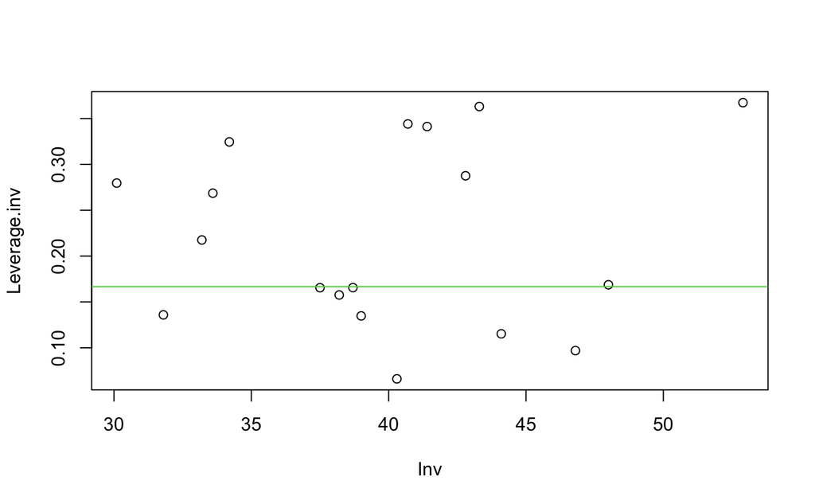

```r
Leverage.inv<-hatvalues(backward_model)
Cooks.Dist.inv<-cooks.distance(backward_model)
Inv <- salary_data$salary
# plotting the influence measures against their x value - Invoices
n=24
plot(Leverage.inv~Inv)
abline(h=4/n, col=3)
```

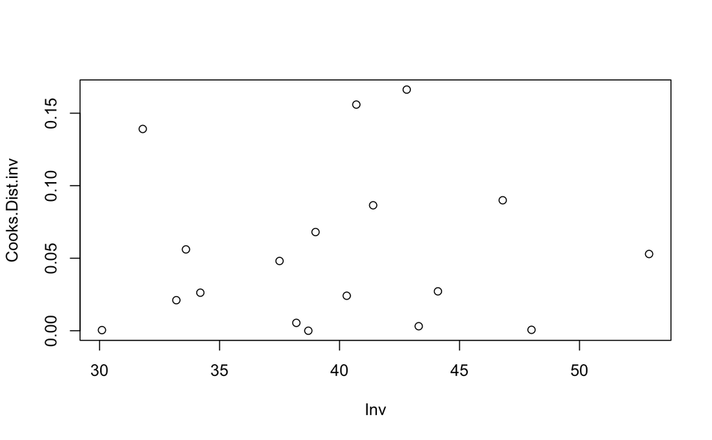

```r
plot(Cooks.Dist.inv~Inv)
abline(h=4/(n-2), col=2)
```

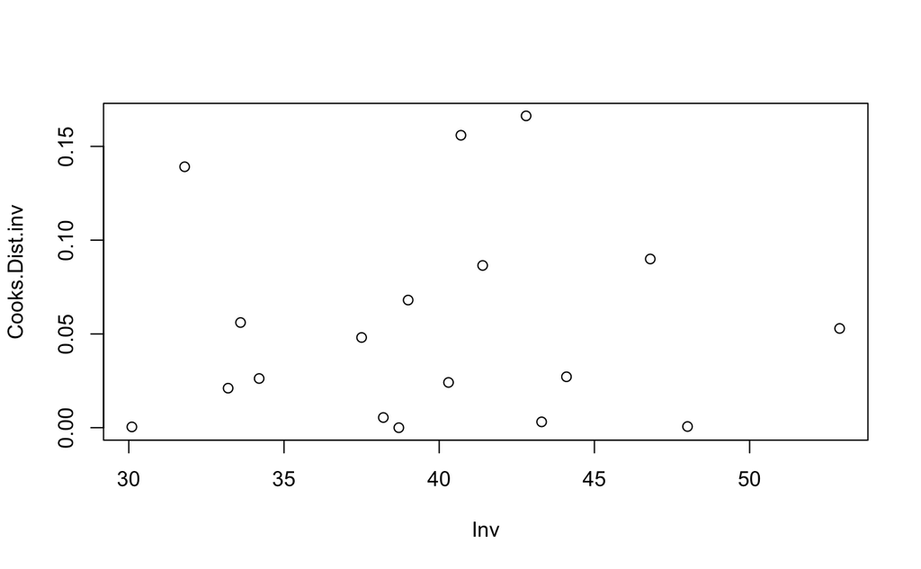

```r
plot(Cooks.Dist.inv~Inv)
abline(h=4/(n-2), col=2)
```

## Question 18

```r
Time <-c(78.8,309.5,184.5,69.6,68.8,95.7,112.3,171.9,177.8,65.8,51.2,59.6,85.4,138.1,125.7,70.1,342.9,70.3,124.9,90,111.7,104.7,82.1,199.8,256.9,179.7,296.6,159.6,182.1,173,216,329.8,325.3,47.8,57,59.4,59.2,84.4,202.1,46.6,257.5,167.1,418.1,302.2,87.2)
DArea <-c(3.6,5.33,6.29,2.2,1.44,5.4,6.6,7.9,4.88,0.85,1.45,4.1,3.89,5.48,5.48,3.78,19.58,1.5,4.83,1.89,3.43,33.18,4.22,7.43,9.98,22.53,45,10.36,10.36,22.5,23.07,42.67,30.67,1.01,2.52,2.16,2.14,7.74,13.65,4.22,20.73,7.48,7.21,10.89,3.24)
CCost <-c(82.4,422.3,179.8,100,103,134.4,173.2,207.9,327.7,56.2,46.8,118.9,113.3,309,309,106.1,374.5,98.3,99.3,60,67.4,1123.6,123.6,222.9,498,563.3,749.1,187.3,187.3,500.5,701.7,1066.8,766.7,30,65.5,63.7,68.4,187.3,421.4,107.7,1264.1,220.1,336.2,641.4,70.2)
Dwgs <-c(6,12,9,5,5,5,5,7,9,3,3,6,6,6,6,5,7,5,6,5,5,9,6,9,15,9,9,10,10,9,12,12,15,4,5,5,4,5,9,6,11,7,11,8,6)
Length <-c(90,126,78,60,60,60,180,188,336,25,50,114,108,128,128,90,430,50,68,64,70,273,95,73,185,395,450,140,140,308,438,405,902,35,70,60,70,242,369,124,860,220,285,560,90)
Spans <-c(1,2,1,1,1,1,3,2,2,1,1,2,2,2,2,1,6,1,1,1,1,2,1,1,3,6,5,3,3,3,4,4,7,1,1,1,1,5,1,1,5,3,3,5,1)
bridge <-cbind(Time,DArea,CCost,Dwgs,Length,Spans)
bridge=data.frame(bridge)
head(bridge)
```

|  | Time | DArea | CCost | Dwgs | Length | Spans |
| --- | --- | --- | --- | --- | --- | --- |
| 1 | 78.8 | 3.60 | 82.4 | 6 | 90 | 1 |
| 2 | 309.5 | 5.33 | 422.3 | 12 | 126 | 2 |
| 3 | 184.5 | 6.29 | 179.8 | 9 | 78 | 1 |
| 4 | 69.6 | 2.20 | 100.0 | 5 | 60 | 1 |
| 5 | 68.8 | 1.44 | 103.0 | 5 | 60 | 1 |
| 6 | 95.7 | 5.40 | 134.4 | 5 | 60 | 1 |

```r
# Log transform the variables
bridge_log <- data.frame(
  logTime = log(bridge$Time),
  logDArea = log(bridge$DArea),
  logCCost = log(bridge$CCost),
  logDwgs = log(bridge$Dwgs),
  logLength = log(bridge$Length),
  logSpans = log(bridge$Spans)
)

# View the first few rows of the transformed data
head(bridge_log)
```

|  | logTime | logDArea | logCCost | logDwgs | logLength | logSpans |
| --- | --- | --- | --- | --- | --- | --- |
| 1 | 4.366913 | 1.2809338 | 4.411585 | 1.791759 | 4.499810 | 0.0000000 |
| 2 | 5.734958 | 1.6733512 | 6.045716 | 2.484907 | 4.836282 | 0.6931472 |
| 3 | 5.217649 | 1.8389611 | 5.191845 | 2.197225 | 4.356709 | 0.0000000 |
| 4 | 4.242765 | 0.7884574 | 4.605170 | 1.609438 | 4.094345 | 0.0000000 |
| 5 | 4.231204 | 0.3646431 | 4.634729 | 1.609438 | 4.094345 | 0.0000000 |
| 6 | 4.561218 | 1.6863990 | 4.900820 | 1.609438 | 4.094345 | 0.0000000 |

```r
NA
```

```r
library(leaps)

# Perform All Subsets Regression
all_subsets <- regsubsets(logTime ~ ., data = bridge_log, nvmax = 5,nbest = 2)

# Summary of the best models
summary(all_subsets)
```

```
Subset selection object
Call: regsubsets.formula(logTime ~ ., data = bridge_log, nvmax = 5,
    nbest = 2)
5 Variables  (and intercept)
          Forced in Forced out
logDArea      FALSE      FALSE
logCCost      FALSE      FALSE
logDwgs       FALSE      FALSE
logLength     FALSE      FALSE
logSpans      FALSE      FALSE
2 subsets of each size up to 5
Selection Algorithm: exhaustive
         logDArea logCCost logDwgs logLength logSpans
1  ( 1 ) " "      " "      "*"     " "       " "
1  ( 2 ) " "      "*"      " "     " "       " "
2  ( 1 ) " "      " "      "*"     " "       "*"
2  ( 2 ) " "      "*"      "*"     " "       " "
3  ( 1 ) " "      "*"      "*"     " "       "*"
3  ( 2 ) "*"      " "      "*"     " "       "*"
4  ( 1 ) "*"      "*"      "*"     " "       "*"
4  ( 2 ) " "      "*"      "*"     "*"       "*"
5  ( 1 ) "*"      "*"      "*"     "*"       "*"
```

```r
# Modify some graphical parameters
par(mfrow = c(1, 3))
par(cex.axis = 1.5)
par(cex.lab = 1.5)

AllSubsets <- regsubsets(logTime ~ ., data = bridge_log, nvmax = 10, nbest = 1)
AllSubsets.summary <- summary(AllSubsets)
plot(1:10, AllSubsets.summary$adjr2, xlab = "subset size", ylab = "adjusted R-squared",
    type = "b")
```

[output not shown]

## Question 19

```r
price<-c(12688,11500,11650,10995,6200,9500,8700,12500,10488,5988,7288,3590,2800,6995,4900,2488,4200,12990,14500,10900,13500,12000,8500,4388,3000,3900,3350,10500,12988,6500,12900,9000,7000,5900,2500)
sunroof<-c(0,0,0,1,0,0,0,0,1,0,1,0,0,1,0,0,1,1,1,1,1,0,0,0,0,0,0,0,0,0,1,0,0,0,0)
age<-c(1,1,1,2,3,3,3,2,4,4,5,5,6,7,7,7,8,1,3,3,3,3,3,4,7,8,8,3,1,3,2,2,6,4,6)
odometer<-c(8200,27000,3000,27000,55000,22000,25000,23800,20000,37000,84000,55000,62000,78000,60000,67000,65000,1300,31000,4000,23000,89000,34000,80000,95000,90000,91000,17000,21000,73000,19000,32000,56000,110000,92000)
auto<-c(0,1,0,1,1,0,1,0,0,0,1,0,0,1,0,1,1,1,1,1,0,0,1,0,0,0,0,0,1,0,0,0,0,1,0)
aircon<-c(1,1,1,1,1,0,1,1,1,1,1,0,1,1,1,1,1,1,1,1,1,1,1,1,1,1,1,1,1,1,1,1,1,1,1)
nocyl<-c(8,8,8,8,4,8,8,8,8,4,4,4,4,4,8,4,6,8,8,8,8,8,8,4,4,8,8,8,8,8,8,8,8,8,4)
colour<-c(1,2,3,4,4,3,5,4,7,3,5,6,5,1,7,1,5,7,7,6,6,7,7,5,5,1,6,1,7,7,6,5,7,5,5)
gtmodel<-c(1,0,1,0,0,0,0,1,1,0,0,0,0,0,1,0,0,0,1,0,1,1,0,0,0,1,1,1,1,0,0,0,1,0,0)
cars=cbind.data.frame(price, sunroof,age,odometer,auto,aircon,nocyl,colour,gtmodel)
cars$sunroof=as.factor(cars$sunroof)
cars$auto=as.factor(cars$auto)
cars$aircon=as.factor(cars$aircon)
cars$colour=as.factor(cars$colour)
cars$gtmodel=as.factor(cars$gtmodel)
head(cars)
```

|  | price | sunroof | age | odometer | auto | aircon | nocyl | colour | gtmodel |
| --- | --- | --- | --- | --- | --- | --- | --- | --- | --- |
| 1 | 12688 | 0 | 1 | 8200 | 0 | 1 | 8 | 1 | 1 |
| 2 | 11500 | 0 | 1 | 27000 | 1 | 1 | 8 | 2 | 0 |
| 3 | 11650 | 0 | 1 | 3000 | 0 | 1 | 8 | 3 | 1 |
| 4 | 10995 | 1 | 2 | 27000 | 1 | 1 | 8 | 4 | 0 |
| 5 | 6200 | 0 | 3 | 55000 | 1 | 1 | 4 | 4 | 0 |
| 6 | 9500 | 0 | 3 | 22000 | 0 | 0 | 8 | 3 | 0 |

```r
# Perform All Subsets Regression
all_subsets <- regsubsets(price ~ ., data = cars, nvmax = 8, nbest = 2)

# Summary of the best models
summary(all_subsets)
```

```
Subset selection object
Call: regsubsets.formula(price ~ ., data = cars, nvmax = 8, nbest = 2)
13 Variables  (and intercept)
         Forced in Forced out
sunroof1     FALSE      FALSE
age          FALSE      FALSE
odometer     FALSE      FALSE
auto1        FALSE      FALSE
aircon1      FALSE      FALSE
nocyl        FALSE      FALSE
colour2      FALSE      FALSE
colour3      FALSE      FALSE
colour4      FALSE      FALSE
colour5      FALSE      FALSE
colour6      FALSE      FALSE
colour7      FALSE      FALSE
gtmodel1     FALSE      FALSE
2 subsets of each size up to 8
Selection Algorithm: exhaustive
         sunroof1 age odometer auto1 aircon1 nocyl colour2 colour3 colour4 colour5 colour6 colour7 gtmodel1
1  ( 1 ) " "      "*" " "      " "   " "     " "   " "     " "     " "     " "     " "     " "     " "
1  ( 2 ) " "      " " "*"      " "   " "     " "   " "     " "     " "     " "     " "     " "     " "
2  ( 1 ) "*"      "*" " "      " "   " "     " "   " "     " "     " "     " "     " "     " "     " "
2  ( 2 ) " "      "*" " "      " "   " "     " "   " "     " "     " "     " "     " "     " "     "*"
3  ( 1 ) "*"      "*" " "      " "   " "     " "   " "     " "     " "     " "     " "     " "     "*"
3  ( 2 ) "*"      "*" " "      " "   " "     "*"   " "     " "     " "     " "     " "     " "     " "
4  ( 1 ) "*"      "*" " "      " "   " "     "*"   " "     " "     " "     " "     " "     " "     "*"
4  ( 2 ) "*"      "*" " "      " "   " "     " "   "*"     " "     " "     " "     " "     " "     "*"
5  ( 1 ) "*"      "*" " "      " "   " "     "*"   "*"     " "     " "     " "     " "     " "     "*"
5  ( 2 ) "*"      "*" " "      "*"   " "     "*"   " "     " "     " "     " "     " "     " "     "*"
6  ( 1 ) "*"      "*" " "      "*"   " "     "*"   "*"     " "     " "     " "     " "     " "     "*"
6  ( 2 ) "*"      "*" " "      " "   " "     "*"   "*"     " "     " "     "*"     " "     " "     "*"
7  ( 1 ) "*"      "*" " "      "*"   "*"     "*"   "*"     " "     " "     " "     " "     " "     "*"
7  ( 2 ) "*"      "*" " "      "*"   " "     "*"   "*"     "*"     " "     " "     " "     " "     "*"
8  ( 1 ) "*"      "*" " "      "*"   "*"     "*"   "*"     " "     "*"     " "     " "     " "     "*"
8  ( 2 ) "*"      "*" " "      "*"   "*"     "*"   "*"     "*"     " "     " "     " "     " "     "*"
```

```r
# Modify some graphical parameters
par(mfrow = c(1, 3))
par(cex.axis = 1.5)
par(cex.lab = 1.5)

AllSubsets <- regsubsets(price ~ ., data = cars, nvmax = 8, nbest = 1)
AllSubsets.summary <- summary(AllSubsets)
plot(1:8, AllSubsets.summary$adjr2, xlab = "subset size", ylab = "adjusted R-squared",
    type = "b")
plot(1:8, AllSubsets.summary$cp, xlab = "subset size", ylab = "Mallows' Cp", type = "b")
```

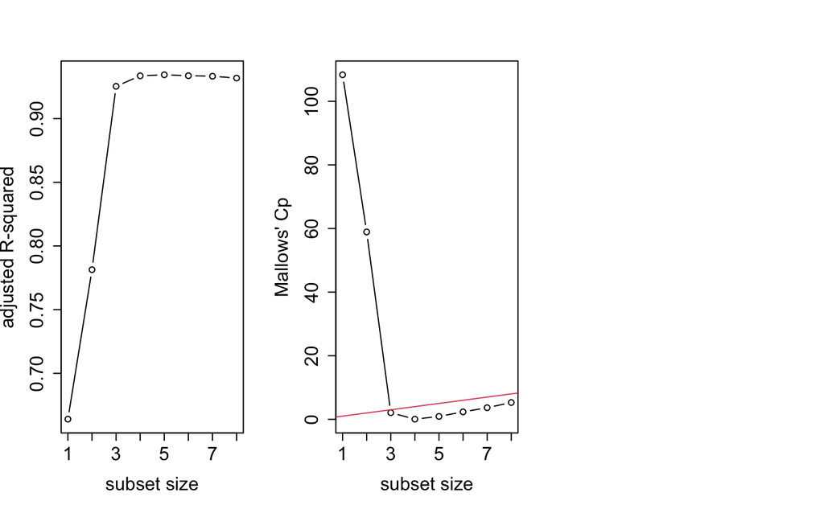

```r
abline(0, 1, col = 2)
plot(1:8, AllSubsets.summary$bic, xlab = "subset size", ylab = "BIC", type = "b")
```

```r
AllSubsets.summary$adjr2
```

```
[1] 0.6640292 0.7813913 0.9253426 0.9335728 0.9344115 0.9336784 0.9332649 0.9318055
```

```r
AllSubsets.summary$cp
```

```
[1] 108.35728623  58.92893024   2.09033142   0.04849733   0.90780987   2.34142674   3.64812214   5.28623745
```

```r
AllSubsets.summary$bic
```

```
[1] -32.10975 -44.67233 -79.83128 -81.51166 -79.58761 -76.87140 -74.37140 -71.37982
```

## Question 20

```r
# Load necessary library
data("attitude")

# View the dataset
View(attitude)

# Define the full model including all explanatory variables
full_model <- lm(rating ~ complaints + privileges + learning + raises + critical + advance, data = attitude)

# Apply forward selection using step function with AIC criterion
forward_selection <- step(lm(rating ~ 1, data = attitude),
                          scope = list(lower = lm(rating ~ 1, data = attitude),
                                       upper = full_model),
                          direction = "forward")
```

```
Start:  AIC=150.93
rating ~ 1

             Df Sum of Sq    RSS    AIC
+ complaints  1   2927.58 1369.4 118.63
+ learning    1   1671.41 2625.6 138.16
+ raises      1   1496.48 2800.5 140.09
+ privileges  1    780.22 3516.7 146.92
<none>                    4297.0 150.93
+ critical    1    105.16 4191.8 152.19
+ advance     1    103.35 4193.6 152.20

Step:  AIC=118.63
rating ~ complaints

             Df Sum of Sq    RSS    AIC
+ learning    1   114.733 1254.7 118.00
<none>                    1369.4 118.63
+ raises      1    11.102 1358.3 120.38
+ privileges  1     7.519 1361.9 120.46
+ advance     1     4.151 1365.2 120.54
+ critical    1     0.010 1369.4 120.63

Step:  AIC=118
rating ~ complaints + learning

             Df Sum of Sq    RSS    AIC
<none>                    1254.7 118.00
+ advance     1    75.540 1179.1 118.14
+ privileges  1    30.033 1224.6 119.28
+ raises      1     1.188 1253.5 119.97
+ critical    1     0.002 1254.7 120.00
```

```r
# Print the AIC values and selected model at each step
print(forward_selection)
```

```
Call:
lm(formula = rating ~ complaints + learning, data = attitude)

Coefficients:
(Intercept)   complaints     learning
     9.8709       0.6435       0.2112
```

## Question 21

```r
salary<-c(33.2,40.3,38.7,46.8,41.4,37.5,39,40.7,30.1,52.9,38.2,31.8,43.3,44.1,42.8,33.6,34.2,48)
quality <-c(3.5,5.3,5.1,5.8,4.2,6,6.8,5.5,3.1,7.2,4.5,4.9,8,6.5,6.6,3.7,6.2,7)
experience <- c(9,20,18,33,31,13,25,30,5,47,25,11,23,35,39,21,7,40)
publish <-c(6.1,6.4,7.4,6.7,7.5,5.9,6,4,5.8,8.3,5,6.4,7.6,7,5,4.4,5.5,7)
# Create data frame
data <- data.frame(salary, quality, experience, publish)

# View the first few rows of the data
head(data)
```

|  | salary | quality | experience | publish |
| --- | --- | --- | --- | --- |
| 1 | 33.2 | 3.5 | 9 | 6.1 |
| 2 | 40.3 | 5.3 | 20 | 6.4 |
| 3 | 38.7 | 5.1 | 18 | 7.4 |
| 4 | 46.8 | 5.8 | 33 | 6.7 |
| 5 | 41.4 | 4.2 | 31 | 7.5 |
| 6 | 37.5 | 6.0 | 13 | 5.9 |

```r
# Fit the full model
full_model <- lm(salary ~ quality + experience + publish, data = data)

# Apply backward selection using step function with AIC criterion
backward_selection <- step(full_model, direction = "backward")
```

```
Start:  AIC=22.83
salary ~ quality + experience + publish

             Df Sum of Sq     RSS    AIC
<none>                     41.037 22.834
- quality     1    19.583  60.621 27.857
- publish     1    28.626  69.663 30.359
- experience  1   219.371 260.408 54.094
```

```r
# Summary of the selected model
model_summary <- summary(backward_selection)
model_summary
```

```
Call:
lm(formula = salary ~ quality + experience + publish, data = data)

Residuals:
     Min       1Q   Median       3Q      Max
-2.99395 -1.14220  0.09636  0.83097  2.97914

Coefficients:
            Estimate Std. Error t value Pr(>|t|)
(Intercept) 18.38074    2.45372   7.491 2.92e-06 ***
quality      0.96792    0.37447   2.585  0.02161 *
experience   0.35415    0.04094   8.651 5.45e-07 ***
publish      1.21480    0.38873   3.125  0.00745 **
---
Signif. codes:  0 ‘***’ 0.001 ‘**’ 0.01 ‘*’ 0.05 ‘.’ 0.1 ‘ ’ 1

Residual standard error: 1.712 on 14 degrees of freedom
Multiple R-squared:  0.933, Adjusted R-squared:  0.9186
F-statistic: 64.97 on 3 and 14 DF,  p-value: 1.851e-08
```

```r
# Print the final AIC value
cat("The final AIC value is:", AIC(backward_selection), "\n")
```

```
The final AIC value is: 75.91574
```

```r
# Print the selected variables
cat("The selected variables are:\n")
```

```
The selected variables are:
```

```r
print(names(coef(backward_selection))[-1]) # Exclude the intercept
```

```
[1] "quality"    "experience" "publish"
```

```r
# Print the p-value for "publish"
publish_p_value <- coef(summary(backward_selection))["publish", "Pr(>|t|)"]
cat("The p-value for 'publish' is:", publish_p_value, "\n")
```

```
The p-value for 'publish' is: 0.007452187
```

```r
# Print the estimated sample variance s squared
s_squared <- sigma(backward_selection)^2
cat("The estimated sample variance s squared is approximately:", s_squared, "\n")
```

```
The estimated sample variance s squared is approximately: 2.931232
```

```r
# Predict with confidence intervals for a specific set of values without explicitly creating a new data frame
predictions <- predict(full_model, newdata = data.frame(quality = 5, experience = 10, publish = 6), interval = "confidence")

# Print predictions with confidence intervals
print(predictions)
```

```
       fit      lwr      upr
1 34.05067 32.68707 35.41427
```

Independence check

```r
# Assuming prod.lm1 is your fitted linear model
plot(residuals(prod.lm1) ~ seq_along(residuals(prod.lm1)),
     xlab = "Observation Order",
     ylab = "Residuals",
     main = "Residuals vs Observation Order")
abline(h = 0, col = "red")
# Install the car package if not already installed
install.packages("car")
library(car)

# Perform the Durbin-Watson test
durbinWatsonTest(prod.lm1)
# ACF plot for residuals
acf(residuals(prod.lm1), main = "ACF of Residuals")
```

[output not shown]

1. Plotting Residuals Against Time or Order If the data is time-ordered or has a specific sequence, you can plot the residuals against time or order of the observations. If there is no apparent pattern (like trends or cycles), the residuals are likely independent.
2. Durbin-Watson Test The Durbin-Watson test is a statistical test used to detect the presence of autocorrelation (a specific type of correlation) in the residuals from a regression analysis. A Durbin-Watson statistic around 2 suggests that there is no autocorrelation. Values approaching 0 indicate positive autocorrelation. Values approaching 4 indicate negative autocorrelation.
3. Autocorrelation Function (ACF) Plot An ACF plot of the residuals can help identify any autocorrelation in the residuals. Significant autocorrelation would indicate a violation of the independence assumption.

Summary of Diagnostic Plots When you call plot(prod.lm1), it typically generates the following diagnostic plots:

Residuals vs Fitted Values (Top Left): Checks for linearity and homoscedasticity (constant variance). Normal Q-Q Plot (Top Right): Checks for normality of residuals. Scale-Location Plot (Bottom Left): Checks for homoscedasticity (constant variance). Residuals vs Leverage Plot (Bottom Right): Identifies influential data points.